# Test, adjust for, and report publication bias: a primer

Doing publication bias test in R: a Hands-on guide

# Instructions

This interactive format Rmarkdown/html is used to provide participants with a hands-on guide and R code, which can be directly adjusted to their own publication bias tests.

# Credit

If this tutorial have helped you, please cite the following paper to credit the original authors:

> Nakagawa S, Lagisz M, Jennions M D, et al. Methods for testing publication bias in ecological and evolutionary meta‐analyses. Methods in Ecology and Evolution, 2022, 13(1): 4-21.

> Viechtbauer W. Conducting meta-analyses in R with the metafor package. Journal of statistical software, 2010, 36(3): 1-48.

# Contributors

- Dr. Alfredo Sánchez-Tójar

Department of Evolutionary Biology, Bielefeld University, Bielefeld, 33615, Germany

Email: alfredo.tojar@gmail.com

- Dr. Malgorzata Lagisz

Evolution & Ecology Research Centre, EERC School of Biological, Earth and Environmental Sciences, BEES The University of New South Wales, Sydney, Australia

Email: m.lagisz@unsw.edu.au

- Dr. Yefeng Yang

Evolution & Ecology Research Centre, EERC School of Biological, Earth and Environmental Sciences, BEES The University of New South Wales, Sydney, Australia

Email: yefeng.yang1@unsw.edu.au

Note: We are generally busy with our own research projects, but we will try our best to address your questions about this tutorial if you have any.

# Loading packages

Load the `R` packages used in this tutorial. The main `R` packages used in this tutorial are `metafor` (for effect size calculation and model fitting; Viechtbauer (2010)) and `orchaRd` (for results reporting; Nakagawa et al. (2021)). All other `R` packages are used for data manipulations, visualizations and rmarkdown knitting.

```r
# the following packages are used for knitting, participants do not need to install and load them
# instal.packages('pacman') #install R package 'pacman' if not already installed
pacman::p_load(knitr,
               DT,
               readxl,
               patchwork,
               ggplot2,
               pander,
               formatR,
               rmdformats
               )
```

Below we randomly choose one meta-analysis paper from Costello and Fox (2022)’s dataset as an example to show how to properly test, adjust for and report publication bias.

> Montagano L, Leroux S J, Giroux M A, et al. The strength of ecological subsidies across ecosystems: a latitudinal gradient of direct and indirect impacts on food webs. Ecology Letters, 2019, 22(2): 265-274.

# Load and process data from the example paper

```r
# load package for reading and manipulating data
pacman::p_load(readr,tidyverse)

# load data
dat <- read_csv(file = "data/montagano.et.al.2019.ecol.letts.csv")

# have a look at the data
head(dat)
```

```
## # A tibble: 6 x 15
##   ID       Year Latit~1 Longi~2 Subs  System Taxon Effect2 Study n_sub~3 Subsi~4
##   <chr>   <dbl>   <dbl>   <dbl> <chr> <chr>  <chr> <chr>   <chr>   <dbl>   <dbl>
## 1 Adams_~  2015    68.6 -150.   Nutr~ aquat~ other dir     expe~       3    5.45
## 2 Adams_~  2015    68.6 -150.   Nutr~ aquat~ other dir     expe~       3    4.03
## 3 Adams_~  2015    68.6 -150.   Nutr~ aquat~ other dir     expe~       3    5.07
## 4 Adams_~  2015    68.6 -150.   Nutr~ aquat~ other dir     expe~       3    7.53
## 5 Aristi~  2016    42.0    2.84 Nutr~ aquat~ other dir     expe~       3   72.9
## 6 Aristi~  2016    42.0    2.84 Nutr~ aquat~ other dir     expe~       3   76.2
## # ... with 4 more variables: Subsidy_sd <dbl>, n_nosubsidy <dbl>,
## #   Nosubsidy_mean <dbl>, Nosubsidy_sd <dbl>, and abbreviated variable names
## #   1: Latitude, 2: Longitude, 3: n_subsidy, 4: Subsidy_mean
```

Before conducting publication bias tests, a necessary step is to calculate effect sizes estimates and their sampling variances. Here, we calculate the standardized mean difference (SMD) as effect size:

```r
# load package for performing meta-analysis
library(metafor)

# compute effect sizes and their sampling variances
dat <- escalc(measure = "SMD",
              n1i = n_subsidy, n2i = n_nosubsidy,
              m1i = Subsidy_mean, m2i = Nosubsidy_mean,
              sd1i = Subsidy_sd, sd2i = Nosubsidy_sd,
              append=TRUE, replace=TRUE,
              data = dat)

# have a look at the data
t <- dat %>% DT::datatable()
t
```

|  | ID | Year | Latitude | Longitude | Subs | System | Taxon | Effect2 | Study | n_subsidy | Subsidy_mean | Subsidy_sd | n_nosubsidy | Nosubsidy_mean | Nosubsidy_sd | yi | vi |
| --- | --- | --- | --- | --- | --- | --- | --- | --- | --- | --- | --- | --- | --- | --- | --- | --- | --- |
| 1 | Adams_et_al.2015Frontiers_in_Microbiology | 2015 | 68.633333 | -149.6 | Nutrients | aquatic | other | dir | experimental | 3 | 5.445629587 | 1.455725908 | 3 | 4.237474309 | 2.092605992 | 0.534790098573999 | 0.690500037461066 |
| 2 | Adams_et_al.2015Frontiers_in_Microbiology | 2015 | 68.633333 | -149.6 | Nutrients | aquatic | other | dir | experimental | 3 | 4.025382574 | 0.606552462 | 3 | 3.254957475 | 0.283057816 | 1.29877251631385 | 0.807234170761018 |
| 3 | Adams_et_al.2015Frontiers_in_Microbiology | 2015 | 68.633333 | -149.6 | Nutrients | aquatic | other | dir | experimental | 3 | 5.06916996 | 0.889986581 | 3 | 2.915019763 | 0.479223544 | 2.4047098771121 | 1.14855246609004 |
| 4 | Adams_et_al.2015Frontiers_in_Microbiology | 2015 | 68.633333 | -149.6 | Nutrients | aquatic | other | dir | experimental | 3 | 7.529644269 | 1.523246263 | 3 | 3.883399209 | 0.599029429 | 2.5136522767509 | 1.19320398070125 |
| 5 | Aristi_et_al2016Environmental_Pollution | 2016 | 41.967303 | 2.84065 | Nutrients | aquatic | other | dir | experimental | 3 | 72.88732394 | 20.53252717 | 3 | 69.24882629 | 16.66997256 | 0.15523576525902 | 0.668674845234629 |
| 6 | Aristi_et_al2016Environmental_Pollution | 2016 | 41.967303 | 2.84065 | Nutrients | aquatic | other | dir | experimental | 3 | 76.17370892 | 5.692185753 | 3 | 69.24882629 | 16.66997256 | 0.443592619462434 | 0.683064534336795 |
| 7 | Barrett_et_al.2005Oikos | 2005 | 28.916667 | -113.5 | Marine_debris | terrestrial | vertebrate | asc | descriptive | 2 | 78.1 | 29.4156421 | 2 | 24.9 | 7.14177849 | 1.40228537694958 | 1.24580053480083 |
| 8 | Barrett_et_al.2005Oikos | 2005 | 28.916667 | -113.5 | Seabird_derived | terrestrial | vertebrate | asc | descriptive | 9 | 26.1 | 42.3 | 9 | 8.36 | 4.92 | 0.561000172385761 | 0.230964477594913 |
| 9 | Bartels_et_al.2012Oecologia | 2012 | 68.341944 | 19.156111 | Nutrients | aquatic | other | dir | experimental | 4 | 0.57 | 0.15 | 4 | 0.7 | 0.04 | -1.02868639820119 | 0.566137231615258 |
| 10 | Bartels_et_al.2012Oecologia | 2012 | 68.341944 | 19.156111 | Nutrients | aquatic | other | dir | experimental | 4 | 0.51 | 0.18 | 4 | 0.65 | 0.05 | -0.92058414017421 | 0.552967197446268 |

[output cut: 564 more lines]

# Test for publication bias (i.e., small-study effects and decline effects)

Recall the mathematical formulas used to test for publication bias:

$$y_{i} = \beta_{0} + \beta_{1}se_{i} + \beta_{2}c(year_{j}) + \sum
\beta_{k}x_{k} + \mu_{(b)j} + \mu_{(w)i} + m_{i}, \\ \mu_{(b)j} \sim
N(0,\sigma_{(b)}^2)\\ \mu_{(w)i} \sim N(0,\sigma_{(w)}^2)\\ m_{i} \sim
N(0,\nu_{i})$$

As shown in the slides and the above equation, the extended Egger’s regression model looks complex, but it is not difficult to construct using existing software, for example, the `rma.mv()` function in the R package `metafor` (Viechtbauer (2010)).

```r
# add an unique identifier to each row (i.e. to each effect size) to account for multiple effect sizes nested within the same study. When fitting multi-level meta-analyses, within-study/residual heterogeneity has to be modeled explicitly by including this unit-level variable as a random effect
dat$obsID <- 1:nrow(dat)

# center publication year and other continuous moderator variables to ease interpretation of the results. In this case, we have decided to mean-center Year, so that 0 then represents the mean of Year
dat$Year.c <- dat$Year - mean(dat$Year) # this variable will be used as a predictor to test for decline effects

## add other important moderators to account for heterogeneity to avoid false positive. We use Latitude and  Longitude because they were used as predictor variables in the original paper
## mean-center latitude
dat$Latitude.c <- dat$Latitude - mean(dat$Latitude)
## mean-center longitude
dat$Longitude.c <- dat$Longitude - mean(dat$Longitude)

# create a moderator containing sampling standard errors (SE), which will then be used to test for small-study effects
dat$sei <- sqrt(dat$vi) # the square root of sampling variance corresponds to the sampling standard errors (SE) (more in Figure 1 from Nakagawa et al. 2022)

# simultaneously detect small-study and decline effects
pub_bias_test <- rma.mv(yi, vi,
                        random = list(~ 1 | ID, ~ 1 | obsID), # ID accounts for among-study heterogeneity whereas obsID accounts for within-study/residual heterogeneity
                        mods = ~ sei +
                          Year.c +
                          Latitude.c +
                          Longitude.c,
                        test = "t",
                        method = "REML",
                        data = dat)
```

Let’s have a look at the model results of the above fitted multi-moderator multi-level meta-regression with:

```r
summary(pub_bias_test)
```

```
##
## Multivariate Meta-Analysis Model (k = 574; method: REML)
##
##     logLik    Deviance         AIC         BIC        AICc
## -1315.3257   2630.6514   2644.6514   2675.0586   2644.8511
##
## Variance Components:
##
##             estim    sqrt  nlvls  fixed  factor
## sigma^2.1  2.1705  1.4733     70     no      ID
## sigma^2.2  3.1540  1.7759    574     no   obsID
##
## Test for Residual Heterogeneity:
## QE(df = 569) = 5439.6882, p-val < .0001
##
## Test of Moderators (coefficients 2:5):
## F(df1 = 4, df2 = 569) = 66.6984, p-val < .0001
##
## Model Results:
##
##              estimate      se     tval   df    pval    ci.lb    ci.ub
## intrcpt       -1.6568  0.2883  -5.7466  569  <.0001  -2.2230  -1.0905  ***
## sei            3.7534  0.2311  16.2387  569  <.0001   3.2994   4.2074  ***
## Year.c        -0.0577  0.0350  -1.6473  569  0.1000  -0.1264   0.0111
## Latitude.c    -0.0120  0.0096  -1.2489  569  0.2122  -0.0310   0.0069
## Longitude.c   -0.0017  0.0026  -0.6593  569  0.5100  -0.0069   0.0034
##
## ---
## Signif. codes:  0 '***' 0.001 '**' 0.01 '*' 0.05 '.' 0.1 ' ' 1
```

A more appropriate way is to replace the original sampling standard error estimate by a modified measure of sampling error. A typical version is based on effective sample size.

$$y_{i} = \beta_{0} + \beta_{1}\sqrt{\frac {1} {\tilde{n_i}}} +
\beta_{2}c(year_{j}) + \sum \beta_{k}x_{k} + \mu_{(b)j} + \mu_{(w)i} +
m_{i}, \\ \mu_{(b)j} \sim N(0,\sigma_{(b)}^2)\\ \mu_{(w)i} \sim
N(0,\sigma_{(w)}^2)\\ m_{i} \sim N(0,\nu_{i})$$
First, let’s calculate effective sample size, and calculate the modified measure of effect size uncertainty/precision based on effective sample size:

```r
# write a help function to calculate effective sample size based sampling variance - tilde n
ess.var_cal <- function(dat){(dat$n_subsidy + dat$n_nosubsidy)/(dat$n_subsidy * dat$n_nosubsidy)}

# calculate modified measure of sampling variance
dat$ess.var <- ess.var_cal(dat)

# calculate modified measure of sampling error - square root of tilde n
dat$ess.se <- sqrt(dat$ess.var)
```

Detect publication bias using the modified measure of sampling standard error:

```r
# simultaneously detect small-study and decline effects
pub_bias_test2 <- rma.mv(yi, vi,
                        random = list(~ 1 | ID, ~ 1 | obsID),
                        mods = ~ ess.se +
                          Year.c +
                          Latitude.c +
                          Longitude.c,
                        test = "t",
                        method = "REML",
                        data = dat)
summary(pub_bias_test2)
```

```
##
## Multivariate Meta-Analysis Model (k = 574; method: REML)
##
##     logLik    Deviance         AIC         BIC        AICc
## -1439.3596   2878.7193   2892.7193   2923.1264   2892.9189
##
## Variance Components:
##
##             estim    sqrt  nlvls  fixed  factor
## sigma^2.1  2.2062  1.4853     70     no      ID
## sigma^2.2  4.3188  2.0782    574     no   obsID
##
## Test for Residual Heterogeneity:
## QE(df = 569) = 5048.5163, p-val < .0001
##
## Test of Moderators (coefficients 2:5):
## F(df1 = 4, df2 = 569) = 1.6343, p-val = 0.1641
##
## Model Results:
##
##              estimate      se     tval   df    pval    ci.lb    ci.ub
## intrcpt        2.6552  0.6417   4.1379  569  <.0001   1.3948   3.9155  ***
## ess.se        -1.9205  0.9768  -1.9662  569  0.0498  -3.8390  -0.0020    *
## Year.c        -0.0505  0.0366  -1.3817  569  0.1676  -0.1224   0.0213
## Latitude.c    -0.0015  0.0103  -0.1446  569  0.8851  -0.0216   0.0187
## Longitude.c   -0.0014  0.0028  -0.5188  569  0.6041  -0.0069   0.0040
##
## ---
## Signif. codes:  0 '***' 0.001 '**' 0.01 '*' 0.05 '.' 0.1 ' ' 1
```

# Report publication bias

We see that the model slope $\beta_{2}$ (`Year.c`) is not statistically significant, which indicates that there is no strong evidence for decline effects. Let’s visually see the results of this test (which can be done using the function `bubble_plot()` from the R package `orchaRd`; Nakagawa et al. (2021))

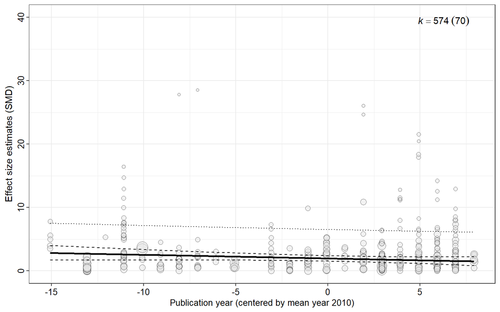

Figure 1. Bubble plot showing the relationship between publication year and effect size magnitude. `orchaRd` package was used to make the figure (Nakagawa et al. (2021))

```r
# load package
# library(orchaRd) # package for visualizations of results of publication bias test
# you need to install the latest version
# a detailed installation tutorial can be found here: https://github.com/daniel1noble/orchaRd
# alternatively, you can run the following code in your R:
#install.packages("pacman")
# pacman::p_load(devtools, tidyverse, metafor, patchwork, R.rsp, emmeans)
# devtools::install_github("daniel1noble/orchaRd", force = TRUE)

# if you have difficulties in installing packages from GitHub repo, we provide the source code below.

source("custom_func.R")

de <- bubble_plot(pub_bias_test, mod = "Year.c",
                  xlab = "Publication year (centered by mean year 2010)", ylab = "Effect size estimates (SMD)",
                  group = "ID", k = TRUE, g = TRUE,
                  data = dat, legend.pos = "none") +
                  ggplot2::ylim(0,40) +
                  theme(axis.text.x = element_text(size = 10, colour = "black"),
                        axis.text.y = element_text(size = 10, colour = "black"),
                        axis.title.x = element_text(size = 10, colour = "black"),
                        plot.title = element_text(size = 10, colour = "black"))
de
```

We can see that there is a negative temporal trend in effect size magnitude (**Figure 1**), but bear in mind that the statistical test showed no statistical significance. The estimate of the slope $\beta_{2}$ is -0.058 (95% CI = -0.126 to 0.011), indicating that effect size magnitude decreased by 0.58 over 10 years. This is equivalent to a medium effect size!!! If we only focus on a dichotomous choice (*p*-value < 0.05 meaning decline effects *vs.* *p*-value > 0.05 meaning no decline effects), we could be neglecting important evidence for the existence of decline effects.

A similar interpretation philosophy can be applied to the test of small-study effects. The model slope $\beta_{1}$ (`sei`) is statistically significant, which indicates that there is evidence for small-study effects (i.e. for funnel plot asymmetry).

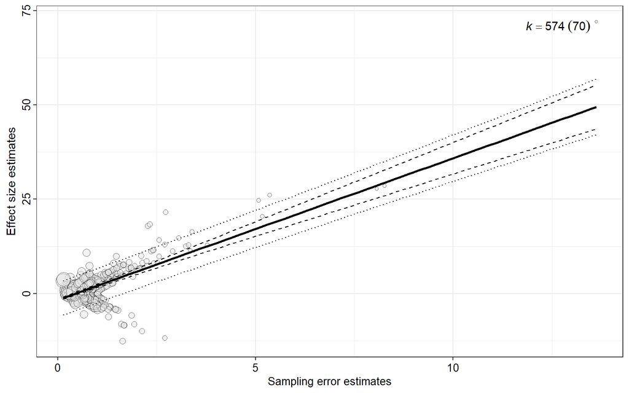

Figure 2. Bubble plot showing the relationship between effect size magnitude and its sampling error (inverse precision). `orchaRd` package was used to make the figure (Nakagawa et al. (2021))

```r
sse <- bubble_plot(pub_bias_test, mod = "sei",
                   xlab = "Sampling error estimates", ylab = "Effect size estimates",
                   group = "ID", k = TRUE, g = TRUE,
                   data = dat, legend.pos = "none") +
                   theme(axis.text.x = element_text(size = 10, colour = "black"),
                         axis.text.y = element_text(size = 10, colour = "black"),
                         axis.title.x = element_text(size = 10, colour = "black"),
                         plot.title = element_text(size = 10, colour = "black"))
sse
```

The visual representation of the model results also confirms that small studies (i.e. those with low precision) are more likely to report large effects (**Figure 2**). The estimate of the slope $\beta_{1}$ is very large - 3.753 (95% CI = 3.299 to 4.207), implying that we should interpret the results and conclusions of this meta-analysis with caution.

We can further explore asymmetry using a traditional funnel plot (Figure 3).

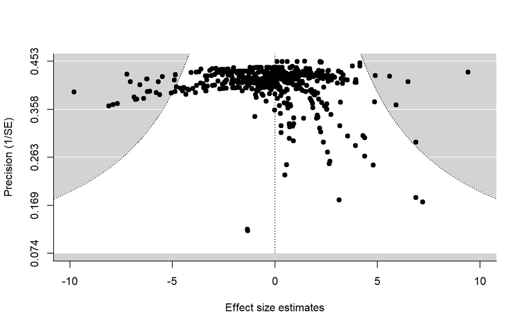

Figure 3. Visual inspection of the funnel plot to identify the small-study effect. `metafor` package was used to make the figure (Viechtbauer (2010))

```r
# make a funnel plot
funnel(pub_bias_test, yaxis = "seinv",
       xlim = c(-10, 10),
       ylab = "Precision (1/SE)",
       xlab = "Effect size estimates")
```

# Adjust for publication bias

Recall the mathematical formulas used to adjust for publication bias:

$$y_{i} = \beta_{0} + \beta_{1}se_{i}^2 + \beta_{2}c(year_{j}) + \sum
\beta_{k}x_{k} + \mu_{(b)j} + \mu_{(w)i} + m_{i}, \\ \mu_{(b)j} \sim
N(0,\sigma_{(b)}^2)\\ \mu_{(w)i} \sim N(0,\sigma_{(w)}^2)\\ m_{i} \sim
N(0,\nu_{i})$$

```r
# fit the above formula
pub_bias_adjust <- rma.mv(yi, vi,
                          random = list(~ 1 | ID, ~ 1 | obsID),
                          mods = ~ vi +
                            Year.c +
                            Latitude.c +
                            Longitude.c, # do not remove intercept via "-1", because the intercept is our focal model estimate
                          test = "t",
                          method = "REML",
                          data = dat)
```

Let’s have a look at the model results of the above fitted multilevel multi-moderator meta-regression with:

```r
summary(pub_bias_adjust)
```

```
##
## Multivariate Meta-Analysis Model (k = 574; method: REML)
##
##     logLik    Deviance         AIC         BIC        AICc
## -1335.4817   2670.9634   2684.9634   2715.3706   2685.1631
##
## Variance Components:
##
##             estim    sqrt  nlvls  fixed  factor
## sigma^2.1  1.6280  1.2759     70     no      ID
## sigma^2.2  3.2621  1.8061    574     no   obsID
##
## Test for Residual Heterogeneity:
## QE(df = 569) = 5204.1927, p-val < .0001
##
## Test of Moderators (coefficients 2:5):
## F(df1 = 4, df2 = 569) = 56.1884, p-val < .0001
##
## Model Results:
##
##              estimate      se     tval   df    pval    ci.lb   ci.ub
## intrcpt        0.7949  0.1994   3.9863  569  <.0001   0.4032  1.1866  ***
## vi             0.6707  0.0451  14.8761  569  <.0001   0.5821  0.7592  ***
## Year.c        -0.0522  0.0317  -1.6455  569  0.1004  -0.1144  0.0101
## Latitude.c    -0.0049  0.0087  -0.5673  569  0.5707  -0.0221  0.0122
## Longitude.c   -0.0017  0.0024  -0.6885  569  0.4914  -0.0064  0.0031
##
## ---
## Signif. codes:  0 '***' 0.001 '**' 0.01 '*' 0.05 '.' 0.1 ' ' 1
```

We can see that the adjusted effect size is statistically significant ($\beta_{0}$ = 0.795 (95% CI = 0.403 to 1.187), p-value < 0.0001). By comparing the original effect size and the adjusted effect size (see table below), we know that although there is evidence of publication bias in this meta-analysis, the results seem robust.

```r
# fit a intercept-only model to estimate the overall effect/pooled effect size
overall_effect_mod <- rma.mv(yi, vi,
                             random = list(~ 1 | ID, ~ 1 | obsID),
                             test = "t",
                             method = "REML",
                             data = dat)

# make a table to compare the original effect size and the adjusted effect size
t1 <- data.frame("Overall effect (pooled mean)" = c(round(overall_effect_mod$b[1],4), round(pub_bias_adjust$b[1],4)),
             "Standard error" = c(round(overall_effect_mod$se,4), round(pub_bias_adjust$se[1],4)),
             "p-value" = c(round(overall_effect_mod$pval,4), round(pub_bias_adjust$pval[1],4)),
             "Lower CI" = c(round(overall_effect_mod$ci.lb,4), round(pub_bias_adjust$ci.lb[1],4)),
             "Upper CI" = c(round(overall_effect_mod$ci.ub,4), round(pub_bias_adjust$ci.ub[1],4)))

colnames(t1) <- c("Overall effect (pooled mean)", "Standard error", "p-value", "Lower CI", "Upper CI")

t1_2 <- t(t1) %>% as.data.frame()
colnames(t1_2) <- c("Original estimate", "Bias-corrected estimate")

t1_2 %>% DT::datatable()
```

|  | Original estimate | Bias-corrected estimate |
| --- | --- | --- |
| Overall effect (pooled mean) | 1.4391 | 0.7949 |
| Standard error | 0.2211 | 0.1994 |
| p-value | 0 | 0.0001 |
| Lower CI | 1.0047 | 0.4032 |
| Upper CI | 1.8734 | 1.1866 |

# Conduct your own analyses and further materials to learn

Participants can modify the above code to test and adjust for publication bias (small-study and decline effects) and (visually) report the associated results. If you prefer an `rmd` version of the code, please refer to our [Github repository: Yefeng0920/2023_ESMARConf_PubBias](https://github.com/Yefeng0920/2023_ESMARConf_PubBias). If you are after a comprehensive theoretical knowledge on the publication bias test in ecology and evolution, we recommend you to thoroughly read our recent methodological paper published in *Methods in Ecology and Evolution* (Nakagawa et al. (2022)). In that paper, we summarized the current practice of publication bias tests in ecology and evolution, and proposed the multilevel multi-moderator meta-regression method approach.

# References

Costello, L., and J. W. Fox. 2022. Decline effects are rare in ecology. Ecology:e3680.

Nakagawa, S., M. Lagisz, M. D. Jennions, J. Koricheva, D. W. Noble, T. H. Parker, A. Sánchez-Tójar, Y. Yang, and R. E. O’Dea. 2022. Methods for testing publication bias in ecological and evolutionary meta-analyses. Methods in Ecology and Evolution 13:4–21.

Nakagawa, S., M. Lagisz, R. E. O’Dea, J. Rutkowska, Y. Yang, D. W. Noble, and A. M. Senior. 2021. The orchard plot: Cultivating a forest plot for use in ecology, evolution, and beyond. Research Synthesis Methods 12:4–12.

Viechtbauer, W. 2010. Conducting meta-analyses in r with the metafor package. Journal of statistical software 36:1–48.